# research

```python
import pandas as pd
import matplotlib.pyplot as plt
import seaborn as sns
import numpy as np
from sklearn.pipeline import make_pipeline
from sklearn.preprocessing import StandardScaler
from sklearn.linear_model import Ridge
from sklearn.model_selection import KFold, GridSearchCV
```

```python
df_nba = pd.read_html("https://www.pyr.bet/merged_nba_box_for_interview.html")[0]
df_wnba = pd.read_html("https://www.pyr.bet/wnba_box_for_interview.html")[0]
df_wnba.rename(columns= {"Ast":"ast","turnovers":"tov"},inplace=True)
```

```python
print(f"NBA df columns: {df_nba.columns}")
print(f"WNBA df columns: {df_wnba.columns}")
```

```
NBA df columns: Index(['player_name', 'games_played', 'games_started', 'minutes', 'fgm', 'fga',
       'fg3m', 'fg3a', 'ftm', 'fta', 'oreb', 'dreb', 'ast', 'stl', 'blk',
       'tov', 'pf', 'points', 'plus_minus', 'offense', 'defense'],
      dtype='object')
WNBA df columns: Index(['player_name', 'games_played', 'games_started', 'minutes', 'fgm', 'fga',
       'fg3m', 'fg3a', 'ftm', 'fta', 'oreb', 'dreb', 'ast', 'stl', 'blk',
       'tov', 'pf', 'points', 'plus_minus'],
      dtype='object')
```

### First short Analysis:

1. The fundamental question is what makes a good player?
2. For most given statistical measures given on the link its some sort of regressions where each statistic gets an asigned weight of positive and negative importace.
3. These regressions are run over years and a lot of players on data.
4. We are given on the NBA the offense and defense scores but not on the WNBA
5. We can imply the relationship between this scores and use that regression in order to get the same scores for the WNBA
6. I know this can lead to a big argument against this way of modeling:
   - Female basketball can be very different than male basketball and what makes a good player on one side might not make it on the other.
   - While this is true I think it is fair to say that a good NBA player would be a good WNBA player if there was a transfer so we will still be capturing good relationships of stats and scoring

I know that I've been given links for common statistical measures in NBA. I believe I don't have enough data (team context) to try to accurately reproduce this statistics. I can't rerun a regression on historical data to get the coefficients in order to score and rank. If the data is proper (I know it's a big if) the offense and defense scores have been calculated using proper statistical models calibrated with historical data. I try to make a simple model capture as much as possible the relationship of the given data and the scorings (Since there is some true underlying relationship that involves this numbers).

Getting pct scores and regressing:

```python
def added_statistics(df: pd.DataFrame) -> pd.DataFrame:
    """
    Getting typical NBA statistics:
    - Percentages
    - True shooting Pct
    - Possesion usage
    """
    df = df.copy()
    df["reb"] = df["oreb"] + df["dreb"]

    # Shooting %
    df["fg_pct"]  = np.where(df["fga"]  > 0, df["fgm"]  / df["fga"], 0.0)
    df["fg3_pct"] = np.where(df["fg3a"] > 0, df["fg3m"] / df["fg3a"], 0.0)
    df["ft_pct"]  = np.where(df["fta"]  > 0, df["ftm"]  / df["fta"], 0.0)

    # True shooting
    ts_denom = (df["fga"] + 0.44 * df["fta"])
    df["ts_pct"] = np.where(ts_denom > 0, df["points"] / (2.0 * ts_denom), 0.0)

    # Usage proxy and per-minute rates
    poss_used = df["fga"] + 0.44 * df["fta"] + df["tov"]
    df["usg_per_min"] = np.where(df["minutes"] > 0, poss_used / df["minutes"], 0.0)

    for col in ["ast","stl","blk","reb","tov","pf","points","plus_minus"]:
        per_min = f"{col.lower()}_per_min"
        df[per_min] = np.where(df["minutes"] > 0, df[col] / df["minutes"], 0.0)

    # Normalize plus/minus a bit (optional)
    df["pm_per100min"] = np.where(df["minutes"] > 0, 100.0 * df["plus_minus"] / df["minutes"], 0.0)
    return df
```

```python
from sklearn.linear_model import LinearRegression

df_nba_stats  = added_statistics(df_nba)
df_wnba_stats = added_statistics(df_wnba)

# Naive Feature Selection (no selection)
exclude_cols = ["player_name", "offense", "defense"]  # exclude identifiers & targets
features = [c for c in df_nba_stats.columns if c not in exclude_cols]

X = df_nba_stats[features].select_dtypes(include="number").fillna(0.0)
y_off = df_nba_stats["offense"]
y_def = df_nba_stats["defense"]

off_model = LinearRegression().fit(X, y_off)
def_model = LinearRegression().fit(X, y_def)

df_nba_stats["offense_est"] = off_model.predict(X)
df_nba_stats["defense_est"] = def_model.predict(X)
df_nba_stats["total_est"]   = df_nba_stats["offense_est"] + df_nba_stats["defense_est"]

X_wnba = df_wnba_stats[features].select_dtypes(include="number").fillna(0.0)
df_wnba_stats["offense_est"] = off_model.predict(X_wnba)
df_wnba_stats["defense_est"] = def_model.predict(X_wnba)
df_wnba_stats["total_est"]   = df_wnba_stats["offense_est"] + df_wnba_stats["defense_est"]

# Quick check: top players
print(df_nba_stats[["player_name","offense","offense_est","defense","defense_est","total_est"]].head())
print(df_wnba_stats[["player_name","offense_est","defense_est","total_est"]].head())
```

```
               player_name  offense  offense_est  defense  defense_est  \
0             Nikola Jokic      6.1     6.249533      1.8     1.585815
1  Shai Gilgeous-Alexander      5.4     7.213403      1.3     1.955547
2             Jayson Tatum      5.1     4.014173      0.9     1.164340
3            Stephen Curry      4.9     4.340255     -0.5    -0.750941
4         Donovan Mitchell      4.5     3.966372      0.4     0.587323

   total_est
0   7.835348
1   9.168951
2   5.178513
3   3.589314
4   4.553695
        player_name  offense_est  defense_est  total_est
0  Napheesa Collier     1.082942     2.519371   3.602313
1    Leonie Fiebich    -0.116768     0.863443   0.746675
2     Jonquel Jones     0.375182     1.843927   2.219109
3   Sabrina Ionescu     1.108772     0.410208   1.518980
4     Kayla McBride     0.985840     0.221787   1.207627
```

```python
df_nba_stats["total_true"] = df_nba_stats["offense"] + df_nba_stats["defense"]
df_nba_stats["rank"] =  df_nba_stats["total_est"].rank(ascending=False).astype(int)
df_nba_stats["true_rank"]  = df_nba_stats["total_true"].rank(ascending=False).astype(int)

print(df_nba_stats[["player_name","rank","true_rank"]].sort_values(by ="true_rank").head(20))
```

```
                 player_name  rank  true_rank
0               Nikola Jokic     2          1
5      Giannis Antetokounmpo     3          2
1    Shai Gilgeous-Alexander     1          3
2               Jayson Tatum     4          4
14             Kawhi Leonard    61          5
6                Luka Doncic     7          6
4           Donovan Mitchell     8          7
20              Franz Wagner    41          8
35         Victor Wembanyama    16          9
47               Joel Embiid   138         10
3              Stephen Curry    17         11
157              Rudy Gobert    22         12
59             Chet Holmgren    42         13
52             Anthony Davis    26         13
37             Jarrett Allen     5         15
9               Kyrie Irving    82         16
187              Alex Caruso    31         17
64         Jaren Jackson Jr.    13         17
13              James Harden     9         19
173              Ivica Zubac    14         20
```

- We observe very big ranking mistakes (Kawhi,Embiid....)
- I will improve this in later models.
- This check is useful for us to know if the extension we are doing to the WNBA is valid

Taking a look at the residuals (for reference [The Truth About Linear Regression](https://www.stat.cmu.edu/~cshalizi/TALR/TALR.pdf)):

1. Our residuals should have a gaussian distribution centered around 0
2. If linearity assumption is okay $E[e_i|X=x] = 0$ (Might check with improved linear regression)

```python
# --- 0) Compute predictions and residuals ---
off_pred = off_model.predict(X)
def_pred = def_model.predict(X)
resid_off = y_off - off_pred
resid_def = y_def - def_pred
```

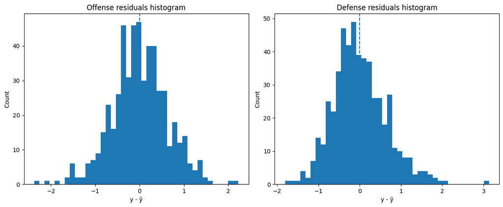

```python
fig, axes = plt.subplots(1, 2, figsize=(12, 5))

axes[0].hist(resid_off, bins=40)
axes[0].axvline(0, linestyle="--")
axes[0].set_title("Offense residuals histogram")
axes[0].set_xlabel("y - ŷ")
axes[0].set_ylabel("Count")

axes[1].hist(resid_def, bins=40)
axes[1].axvline(0, linestyle="--")
axes[1].set_title("Defense residuals histogram")
axes[1].set_xlabel("y - ŷ")
axes[1].set_ylabel("Count")

plt.tight_layout()
plt.show()
```

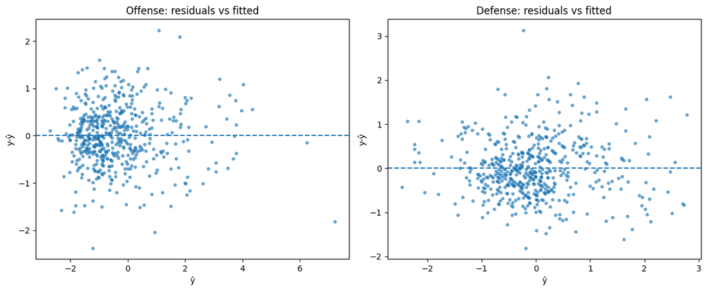

```python
fig, ax = plt.subplots(1,2, figsize=(12,5))
ax[0].scatter(off_model.predict(X), y_off - off_model.predict(X), s=10, alpha=0.6)
ax[0].axhline(0, ls="--"); ax[0].set_title("Offense: residuals vs fitted"); ax[0].set_xlabel("ŷ"); ax[0].set_ylabel("y-ŷ")

ax[1].scatter(def_model.predict(X), y_def - def_model.predict(X), s=10, alpha=0.6)
ax[1].axhline(0, ls="--"); ax[1].set_title("Defense: residuals vs fitted"); ax[1].set_xlabel("ŷ"); ax[1].set_ylabel("y-ŷ")

plt.tight_layout(); plt.show()
```

#### Improved modelling

1. We have used the most naive linear regression on the previous ranking.
2. There are some issues with this:
- Multicollinearity is very high both by construction of the features and by the nature of the features (e.g fgm, fga,fg3m,fg3a)
- We haven't accounted for outliers that might mess with our model (e.g Players that have played less than x ammount of minutes aren't properly statistically tractable)
3. We can now proceed with feature selection and using regularized linear regression for the collinearity (Ridge)

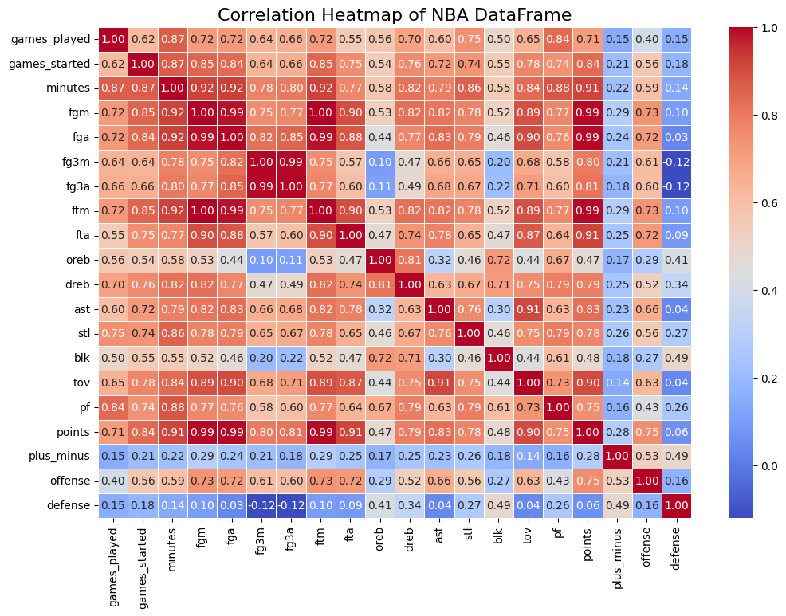

```python
corr_matrix = df_nba.corr(numeric_only=True)  # numeric_only avoids the players column

# Plot heatmap
plt.figure(figsize=(12, 8))
sns.heatmap(corr_matrix, annot=True, cmap="coolwarm", fmt=".2f", linewidths=0.5)
plt.title("Correlation Heatmap of NBA DataFrame", fontsize=16)
plt.show()
```

- I'm going to use feature selection by prioritizing percentage and per minute features that will give us a better idea of performance.
- Will eliminate players from the training dataset that are outliers (with less than x minutes of play)

```python
MIN_MINUTES_NBA  = 300
MIN_MINUTES_WNBA = 200

# Minute Filtering
df_nba_filt  = df_nba_stats.loc[df_nba_stats["minutes"]  >= MIN_MINUTES_NBA].copy()
df_wnba_filt = df_wnba_stats.loc[df_wnba_stats["minutes"] >= MIN_MINUTES_WNBA].copy()

# Column selection
feat_cols = [
    c for c in df_nba_filt.columns
    if c.endswith("_pct") or c.endswith("_per_min") or c in ["pm_per100min", "usg_per_min"]
]
```

```python
# Predictors and predicted:
X_nba  = df_nba_filt[feat_cols].select_dtypes(include="number").fillna(0.0).to_numpy()
y_off  = df_nba_filt["offense"].to_numpy(dtype=float)
y_def  = df_nba_filt["defense"].to_numpy(dtype=float)

# Aligning WNBA cols for safety
X_wnba = df_wnba_filt.reindex(columns=feat_cols).select_dtypes(include="number").fillna(0.0).to_numpy()

# Minute weighting (explained below)
w = np.sqrt(np.clip(df_nba_filt["minutes"].to_numpy(), 1, None))

# CV Ridge to not force te ridge coefficient
cv = KFold(n_splits=5, shuffle=True, random_state=0)
param_grid = {"ridge__alpha": np.logspace(-2, 2, 9)}  # 0.01 … 100

off_cv = GridSearchCV(
    make_pipeline(StandardScaler(), Ridge(random_state=0)),
    param_grid=param_grid, cv=cv, scoring="r2", n_jobs=None
)
def_cv = GridSearchCV(
    make_pipeline(StandardScaler(), Ridge(random_state=0)),
    param_grid=param_grid, cv=cv, scoring="r2", n_jobs=None
)

off_cv.fit(X_nba, y_off, **{"ridge__sample_weight": w})
def_cv.fit(X_nba, y_def, **{"ridge__sample_weight": w})

off_model = off_cv.best_estimator_
def_model = def_cv.best_estimator_

print("Best alpha (offense):", off_cv.best_params_["ridge__alpha"], "CV R^2:", off_cv.best_score_)
print("Best alpha (defense):", def_cv.best_params_["ridge__alpha"], "CV R^2:", def_cv.best_score_)

# Prediction and total scoring
df_nba_filt["offense_est"] = off_model.predict(X_nba)
df_nba_filt["defense_est"] = def_model.predict(X_nba)
df_nba_filt["total_est"]   = df_nba_filt["offense_est"] + df_nba_filt["defense_est"]

df_wnba_filt["offense_est"] = off_model.predict(X_wnba)
df_wnba_filt["defense_est"] = def_model.predict(X_wnba)
df_wnba_filt["total_est"]   = df_wnba_filt["offense_est"] + df_wnba_filt["defense_est"]

# rank
for d in (df_nba_filt, df_wnba_filt):
    d["rank"] = d["total_est"].rank(ascending=False).astype(int)

# Quick view
print(df_nba_filt.sort_values("total_est", ascending=False)[["player_name","total_est","rank"]].head(10))
print(df_wnba_filt.sort_values("total_est", ascending=False)[["player_name","total_est","rank"]].head(10))
```

[output not shown]

```
Best alpha (offense): 10.0 CV R^2: 0.7340885948590667
Best alpha (defense): 100.0 CV R^2: 0.5775805250294453
                 player_name  total_est  rank
1    Shai Gilgeous-Alexander   7.123271     1
0               Nikola Jokic   6.622026     2
5      Giannis Antetokounmpo   4.987011     3
6                Luka Doncic   4.507482     4
59             Chet Holmgren   4.185782     5
35         Victor Wembanyama   4.133269     6
60               Evan Mobley   3.954242     7
187              Alex Caruso   3.926042     8
261          Jaylin Williams   3.925737     9
4           Donovan Mitchell   3.688059    10
           player_name  total_est  rank
14         A'ja Wilson   4.972752     1
0     Napheesa Collier   3.859417     2
5      Breanna Stewart   3.331641     3
29       Nyara Sabally   2.719565     4
13      Nneka Ogwumike   2.621832     5
2        Jonquel Jones   2.223018     6
41  Elizabeth Williams   2.167783     7
3      Sabrina Ionescu   1.941199     8
6         Alanna Smith   1.932277     9
18       Alyssa Thomas   1.846357    10
```

```python
#Define a function to visualize the final equation:
def to_raw_equation(pipe, feat_names, name):
    ridge = pipe.named_steps["ridge"]
    scaler = pipe.named_steps["standardscaler"]
    coef_std = ridge.coef_.astype(float)
    intercept_std = ridge.intercept_.astype(float)
    beta = coef_std / scaler.scale_.astype(float)
    intercept = intercept_std - np.sum(coef_std * scaler.mean_.astype(float) / scaler.scale_.astype(float))
    # build string
    parts = [f"{name} = {intercept:.6f}"]
    for b, f in zip(beta, feat_names):
        parts.append((" + " if b >= 0 else " - ") + f"{abs(b):.6f}·{f}")
    return "".join(parts)
```

```python
# Grab the fitted pipelines
off_pipe = off_model.best_estimator_ if hasattr(off_model, "best_estimator_") else off_model
def_pipe = def_model.best_estimator_ if hasattr(def_model, "best_estimator_") else def_model
print(to_raw_equation(off_pipe,feat_cols,"score offense"))
print(to_raw_equation(def_pipe,feat_cols,"score defense"))
```

[output not shown]

##### Some comments:

1. We observe some weird coefficients: for scoring offense fg_pct,fg3_pct, ft_pct are negative!
- At first thought it might seem to imply that scoring is bad for offense?
- We have a classic multicollinearity effect. Since we are penalizing for it our model finds its best to compensate the very high coefficient of points_per_min with making this ones negatives.
2. This are the benefits of using a simple linear model that we can easily observe this kind of "issues".

```python
# OFFENSE: explicit decomposition
feat_off = ["fg_pct", "fg3_pct", "ft_pct",
            "usg_per_min", "ast_per_min", "tov_per_min", "pf_per_min", "pm_per100min"]
Xo = df_nba_filt[feat_off].fillna(0.0).to_numpy()
Yo = df_nba_filt["offense"].to_numpy(float)

# DEFENSE: explicit decomposition
feat_def = ["stl_per_min", "blk_per_min", "reb_per_min", "pf_per_min", "pm_per100min"]
Xd = df_nba_filt[feat_def].fillna(0.0).to_numpy()
Yd = df_nba_filt["defense"].to_numpy(float)

w = np.sqrt(np.clip(df_nba_filt["minutes"].to_numpy(), 1, None))
cv = KFold(n_splits=5, shuffle=True, random_state=0)
param_grid = {"ridge__alpha": np.logspace(-2, 2, 9)}  # 0.01 ... 100

# offense model
off_cv = GridSearchCV(
    make_pipeline(StandardScaler(), Ridge(random_state=0)),
    param_grid=param_grid, cv=cv, scoring="r2"
)
off_cv.fit(Xo, Yo, ridge__sample_weight=w)
off_model = off_cv.best_estimator_

# defense model
def_cv = GridSearchCV(
    make_pipeline(StandardScaler(), Ridge(random_state=0)),
    param_grid=param_grid, cv=cv, scoring="r2"
)
def_cv.fit(Xd, Yd, ridge__sample_weight=w)
def_model = def_cv.best_estimator_

print("Best alpha (offense):", off_cv.best_params_["ridge__alpha"])
print("Best alpha (defense):", def_cv.best_params_["ridge__alpha"])

# --- print explicit equations (raw feature units) ---
print(to_raw_equation(off_model, feat_off, "score_offense"))
print()
print(to_raw_equation(def_model, feat_def, "score_defense"))
```

```
Best alpha (offense): 100.0
Best alpha (defense): 100.0
score_offense = -5.131694 + 5.311707·fg_pct + 1.125051·fg3_pct - 0.017383·ft_pct + 7.255830·usg_per_min + 7.895021·ast_per_min - 19.034124·tov_per_min - 8.924161·pf_per_min + 0.041567·pm_per100min

score_defense = -2.090506 + 28.270457·stl_per_min + 22.832488·blk_per_min + 3.438736·reb_per_min + 1.529089·pf_per_min + 0.037185·pm_per100min
```

```python
# --- NBA predictions ---
df_nba_filt["offense_est"] = off_model.predict(Xo)
df_nba_filt["defense_est"] = def_model.predict(Xd)
df_nba_filt["total_est"]   = df_nba_filt["offense_est"] + df_nba_filt["defense_est"]

# --- WNBA predictions (align feature sets) ---
Xo_w = df_wnba_filt.reindex(columns=feat_off).fillna(0.0).to_numpy()
Xd_w = df_wnba_filt.reindex(columns=feat_def).fillna(0.0).to_numpy()

df_wnba_filt["offense_est"] = off_model.predict(Xo_w)
df_wnba_filt["defense_est"] = def_model.predict(Xd_w)
df_wnba_filt["total_est"]   = df_wnba_filt["offense_est"] + df_wnba_filt["defense_est"]

for d in (df_nba_filt, df_wnba_filt):
    d["rank"] = d["total_est"].rank(ascending=False).astype(int)

# --- Print top 15 ---
print("NBA Top 15:")
print(df_nba_filt.sort_values("total_est", ascending=False)
      [["player_name","offense_est","defense_est","total_est","rank"]].head(15))

print("\nWNBA Top 15:")
print(df_wnba_filt.sort_values("total_est", ascending=False)
      [["player_name","offense_est","defense_est","total_est","rank"]].head(15))
```

```
NBA Top 15:
                 player_name  offense_est  defense_est  total_est  rank
1    Shai Gilgeous-Alexander     5.025417     1.925336   6.950753     1
0               Nikola Jokic     4.298877     1.798131   6.097007     2
5      Giannis Antetokounmpo     3.897571     1.250277   5.147848     3
35         Victor Wembanyama     1.606672     2.996868   4.603540     4
59             Chet Holmgren     1.663956     2.884846   4.548802     5
6                Luka Doncic     3.261412     1.231788   4.493201     6
60               Evan Mobley     2.202719     1.979939   4.182658     7
14             Kawhi Leonard     2.767625     1.298374   4.065999     8
4           Donovan Mitchell     3.295520     0.748309   4.043829     9
74            Jalen Williams     2.716248     1.216484   3.932732    10
52             Anthony Davis     2.076198     1.693187   3.769385    11
187              Alex Caruso     0.961908     2.756475   3.718383    12
2               Jayson Tatum     2.887677     0.724688   3.612365    13
```

[output cut: 20 more lines]

```python
# True ranking (given offense + defense from the dataset)
df_nba_filt["total_true"] = df_nba_filt["offense"] + df_nba_filt["defense"]
df_nba_filt["true_rank"]  = df_nba_filt["total_true"].rank(ascending=False).astype(int)

# Comparison table: true vs predicted rank
nba_rank_compare = df_nba_filt[["player_name", "true_rank", "rank"]] \
                     .sort_values("true_rank")

print(nba_rank_compare.head(20))   # show top 20 for example
```

[output not shown]

### Final Remarks:

1. I have decided to use a ridge model to account for multicollinearity and gain explainability
2. This has led us to identify weirdness in the coefficients and therefore try to explicitly define what makes a good model by choosing the features both for offense and defense.
3. The idea of choosing linear models is very common in Quantitative Finance for two main reasons:
   - You understand what your bets are in terms of decomposing them into factors.
   - You can do ex-post revision of your bets to both attribute risk and performance
4. I assume (although there are not that many tradable assets to hedge positions) this is something that can be done aswell in sports betting.
5. More complex models could've been used in order to fit better the data (and the similarities between predicted off and def scores with the real ones would've been much closer). But I, in general, strive for simplicity because I believe it is very useful in order to understand where you are betting.
6. Because of that we still observe significant discrepancies between players that should be high in the ranking but are not in our predictive ranking.
7. A boosted tree regression would've probably fixed this but I believe the arguments above explain more what I know or believe to be a good way of modelling. This doesn't mean I believe I know how to accurately model sports and I still believe I would need to learn a lot from both of you.
8. Other useful checks would've been checking residuals vs predictors and check for mean 0 of residuals given this variables.